# Statistical Inference Course Project 2

Ben Weinert

March 12, 2016

# Project

This report is for second part of the course project of the Coursera course “Statistical Inference” which is a part of specialization “Data Science”. In this second part, we perform basic inferential analyses using the ToothGrowth data in the R datasets package.

As per the help file of this dataset, the response is the length of odontoblasts (teeth) in each of 10 guinea pigs at each of three dose levels of Vitamin C (0.5, 1, and 2 mg) with each of two delivery methods (orange juice or ascorbic acid).

## Loading and Viewing the Dataset

```r
#Load the Dataset
library(ggplot2)
library(datasets)
data(ToothGrowth)

#View the contents
str(ToothGrowth)
```

```
## 'data.frame':    60 obs. of  3 variables:
##  $ len : num  4.2 11.5 7.3 5.8 6.4 10 11.2 11.2 5.2 7 ...
##  $ supp: Factor w/ 2 levels "OJ","VC": 2 2 2 2 2 2 2 2 2 2 ...
##  $ dose: num  0.5 0.5 0.5 0.5 0.5 0.5 0.5 0.5 0.5 0.5 ...
```

```r
head(ToothGrowth)
```

```
##    len supp dose
## 1  4.2   VC  0.5
## 2 11.5   VC  0.5
## 3  7.3   VC  0.5
## 4  5.8   VC  0.5
## 5  6.4   VC  0.5
## 6 10.0   VC  0.5
```

```r
#Change dose from numeric to factor
ToothGrowth$dose<-as.factor(ToothGrowth$dose)
```

## Summarize the data

```r
summary(ToothGrowth)
```

```
##       len        supp     dose
##  Min.   : 4.20   OJ:30   0.5:20
##  1st Qu.:13.07   VC:30   1  :20
##  Median :19.25           2  :20
##  Mean   :18.81
##  3rd Qu.:25.27
##  Max.   :33.90
```

```r
table(ToothGrowth$dose,ToothGrowth$supp)
```

```
##
##       OJ VC
##   0.5 10 10
##   1   10 10
##   2   10 10
```

## Perform a basic exploratory analysis

```r
#Check the mean of the two supplements
DataSupp<-split(ToothGrowth$len, ToothGrowth$supp)
sapply(DataSupp, mean)
```

```
##       OJ       VC
## 20.66333 16.96333
```

There is a difference in the mean length for the supplements. Now check the overlap of the supplements using a graph.

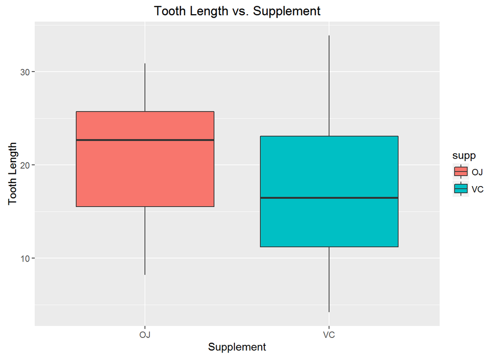

```r
#make a plot of length vs supplement
ggplot(aes(x=supp,y=len),data=ToothGrowth) +
        geom_boxplot(aes(fill=supp)) +
        xlab("Supplement") +
        ylab("Tooth Length") +
        ggtitle("Tooth Length vs. Supplement")
```

There does not appear to be a large difference in tooth length for the two supplements due to the large overlap. A more in depth analysis using confidence intervals is necessary.

```r
#Check the mean of the three doses
DataDose<-split(ToothGrowth$len, ToothGrowth$dose)
sapply(DataDose, mean)
```

```
##    0.5      1      2
## 10.605 19.735 26.100
```

The mean of the tooth length is increasing with the dose. Now check the observations vs dose with a graph.

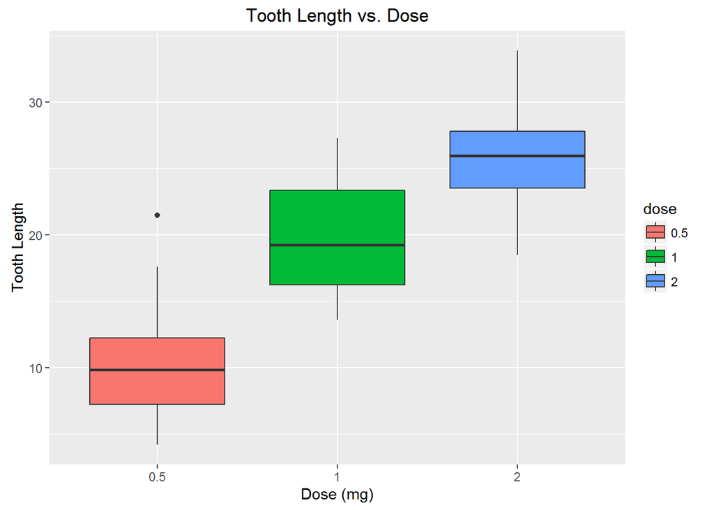

```r
#make a plot of length vs dose
ggplot(aes(x=dose,y=len),data=ToothGrowth) +
        geom_boxplot(aes(fill=dose)) +
        xlab("Dose (mg)") +
        ylab("Tooth Length") +
        ggtitle("Tooth Length vs. Dose")
```

The distribution of the tooth length appears to increase with dosage in this quick exploratory analysis.

Finally make a graph splitting the data into dosage and supplement

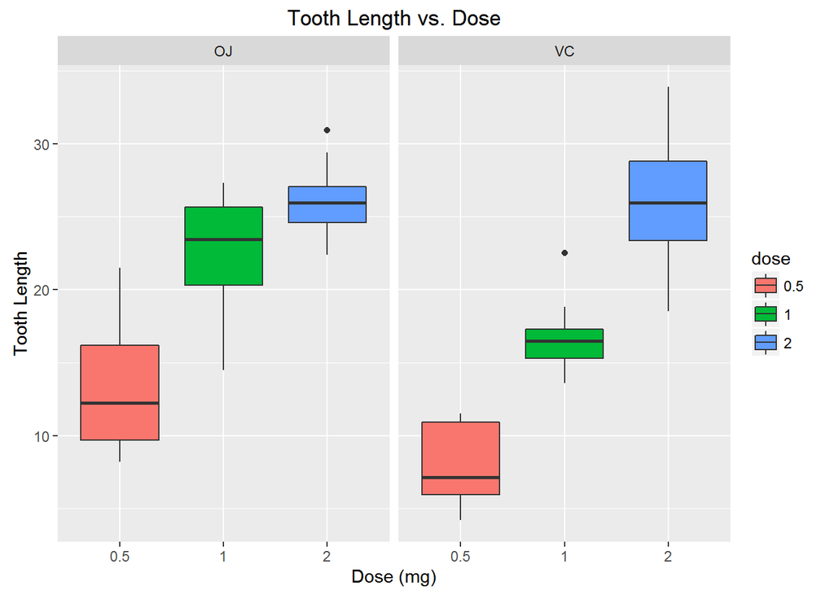

```r
#make a plot of length vs dose
ggplot(aes(x=dose,y=len),data=ToothGrowth) +
        geom_boxplot(aes(fill=dose)) +
        facet_grid(.~supp) +
        xlab("Dose (mg)") +
        ylab("Tooth Length") +
        ggtitle("Tooth Length vs. Dose")
```

The trend with dosage is seen for both supplements.

## Perform Statistcal Inference Tests

Now we will use t test to determine if either the supplement or dosage has an affect on the tooth length. First we will look at the supplement.

```r
t.test(len~supp,data=ToothGrowth)
```

```
##
##  Welch Two Sample t-test
##
## data:  len by supp
## t = 1.9153, df = 55.309, p-value = 0.06063
## alternative hypothesis: true difference in means is not equal to 0
## 95 percent confidence interval:
##  -0.1710156  7.5710156
## sample estimates:
## mean in group OJ mean in group VC
##         20.66333         16.96333
```

The 95% confidence interval for the t test includes zero. This means that we can not reject the null hypothesis, that the supplement has no affect on the tooth length. Additionally the p value is about 6.1%, which is greater than the 5% used in most significance tests.

Now we will test to see if there is an affect on the the tooth length due to the dosage. To do this we will test the three dosages in pairs to see if they are the same. In doing this we assume the data is not paired, and the variances are equal.

```r
#Compare 1mg dosage to 0.5mg to see if they are the same
t.test(ToothGrowth$len[ToothGrowth$dose==1],ToothGrowth$len[ToothGrowth$dose==0.5],paired=FALSE,var.equal=TRUE)
```

```
##
##  Two Sample t-test
##
## data:  ToothGrowth$len[ToothGrowth$dose == 1] and ToothGrowth$len[ToothGrowth$dose == 0.5]
## t = 6.4766, df = 38, p-value = 1.266e-07
## alternative hypothesis: true difference in means is not equal to 0
## 95 percent confidence interval:
##   6.276252 11.983748
## sample estimates:
## mean of x mean of y
##    19.735    10.605
```

```r
#Compare 2mg dosage to 0.5mg to see if they are the same
t.test(ToothGrowth$len[ToothGrowth$dose==2],ToothGrowth$len[ToothGrowth$dose==0.5],paired=FALSE,var.equal=TRUE)
```

```
##
##  Two Sample t-test
##
## data:  ToothGrowth$len[ToothGrowth$dose == 2] and ToothGrowth$len[ToothGrowth$dose == 0.5]
## t = 11.799, df = 38, p-value = 2.838e-14
## alternative hypothesis: true difference in means is not equal to 0
## 95 percent confidence interval:
##  12.83648 18.15352
## sample estimates:
## mean of x mean of y
##    26.100    10.605
```

```r
#Compare 2mg dosage to 1mg to see if they are the same
t.test(ToothGrowth$len[ToothGrowth$dose==2],ToothGrowth$len[ToothGrowth$dose==1],paired=FALSE,var.equal=TRUE)
```

```
##
##  Two Sample t-test
##
## data:  ToothGrowth$len[ToothGrowth$dose == 2] and ToothGrowth$len[ToothGrowth$dose == 1]
## t = 4.9005, df = 38, p-value = 1.811e-05
## alternative hypothesis: true difference in means is not equal to 0
## 95 percent confidence interval:
##  3.735613 8.994387
## sample estimates:
## mean of x mean of y
##    26.100    19.735
```

For all three of the dosage pairs, the 95% confidence level does not contain zero. The p value is also orders of magnitude below 5% for each pair. This means that the tooth length is not the same for the dosages, and as we saw with the boxplots the length increases with dosage. Therefore we can reject the null hypothesis and establish that the tooth length increases with dosage.

## Summary and Assumptions

In creating these tests, a few assumptions were made. It is assumed that there was a random assignment of supplement and dosage to each of the guinea pigs, and that this sample population is representative of the total (although we did not perform a power test as we did not create this sample). For the t tests, it was assumed that the groups were not paired, and that the variances were equal.

We can make two conclusions from the exploratory analysis and statistical inference tests. The first is that the supplement has no affect on the tooth length. The second is that the tooth length of the guinea pigs increases with the dosage.